# Resvaneundersökning i Bålsta tätort 202101-202109

Region Uppsala

2021-11-08

# 1 Sammanfattning

## 1.1 Antal resor

Antalet resor per dygn för hela befolkningen i Bålsta uppgick till 23 584. I genomsnitt gjorde 57 procent av respondenterna åtminstone en resa per dag. Totalt transporterades de boende 436 710 kilometer under en genomsnittsdag summerat över samtliga färdmedel.

## 1.2 Färdmedelsfördelning

Färdmedelsfördelningen för det totala antalet resor visas i Figur 1.1 och färdmedelsfördelningen uttryckt i andelar av den totala sammanlagda ressträckan i Figur 1.2. Vad gäller andelen resor per färdmedel, framgår att bil var det vanligaste färdmedlet och användes för 82 procent av alla resor. Näst vanligast var kollektivtrafik, vilket utgjorde 10 procent av alla resor. Bil var också det vanligaste färdmedlet sett till den sammanlagda ressträckan. En övervägande majoritet (88 %) av färdmedelskilometrarna, som boende i Bålsta förflyttade sig, gjordes med bil.

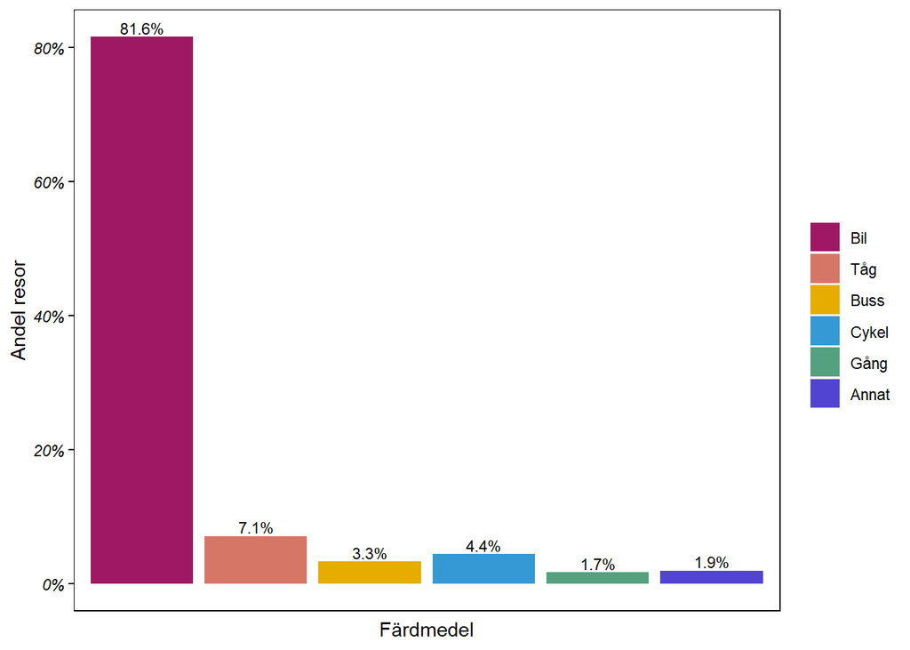

Figure 1.1: Resornas färdmedelsfördelning sett till antalet resor. Notera att kollektivtrafik är redovisat uppdelat på buss och tåg.

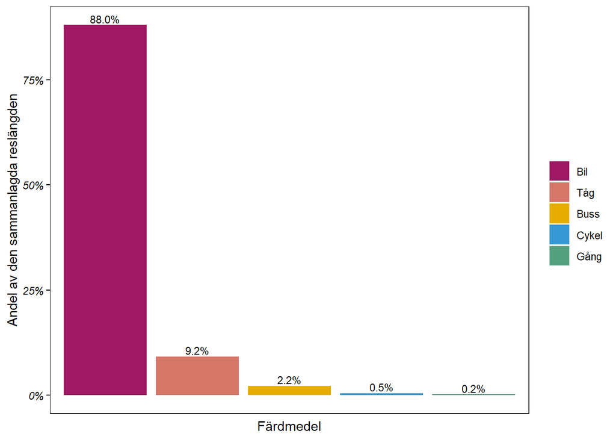

Figure 1.2: Resornas färdmedelsfördelning sett till den sammanlagda ressträckan. Notera att *annat* färdmedel inte är redovisat eftersom information om reslängd saknas för dessa resor.

## 1.3 Fördelning mellan män och kvinnor

Män och kvinnors resande skiljer sig normalt sett åt. I det här fallet gjorde män 1,8 resor per person och dag, medan kvinnor gjorde 1,7. Bland män stod bil för en större del av resorna (83 %) än bland kvinnor (80 %). För kvinnor var istället cykel vanligare än bland män (7 % för kvinnor och 2 % för män).

## 1.5 Vanligaste reserelationer

En av de vanligaste förekommande resorna inom ett delområde skedde inom Södra Bålsta följt av Centrala Bålsta, Kalmarsand och Västerängen. Mellan två delområden var den vanligaste förekommande reserelationen Kalmarsand–Västerängen följt av relationen Västerängen–Centrala Bålsta. När det gäller målpunkter utanför Bålsta, var den vanligaste tätorten Stockholm, vilket också var den vanligaste kommunen för utpendlingsresor.

# 2 Inledning

Följande rapport har tagits fram för att öka kunskapen om dagens resmönster för olika trafikantgrupper i Bålsta. Rapportens resultat avser att ge en bild av hur resandet ser ut en genomsnittlig vardag mellan januari 2021 och augusti 2021. Resultatet utgör ett viktigt underlag för att planera för en hållbar samhällsutveckling och ett hållbart resande.

## 2.1 Metod

Rapporten är baserad på data från Svensk kollektivtrafiks Kollektivtrafikbarometer[^1]. Kollektivtrafikbarometern är en branschgemensam nationell kvalitets- och resvaneundersökning som riktar sig till den svenska allmänheten mellan 15 och 85 år, både de som använder kollektivtrafiken och de som inte gör det. Till grunden av datainsamlingen ligger ett slumpmässigt och representativt individurval ur ett befolkningsregister utifrån postnummerområden.

Till skillnad från de flesta resvaneundersökningar utförs Kollektivtrafikbarometern kontinuerligt med dataleveranser varje månad. Fördelen med en kontinuerlig insamling är att säsongsvariationer kan utjämnas och enskilda händelser (t.ex. mycket regn under insamlingsperioden) inte påverkar resultatet särskilt. Det är dock möjligt att skapa en rapport som inte baseras på alla månader av ett år. Därför bör särskild uppmärksamhet riktas åt vilka månader som dataunderlaget omfattar i den specifika rapporten, se Tabell 2.2 i nästa avsnitt.

Datainsamlingen sker via en inbjudan som skickas via post till personer som ingår i urvalet. Det initiala bortfallet, det vill säga personer med inbjudan som inte svarar, är ett viktigt kvalitetskriterium och är jämförbart med andra resvaneundersökningar. Kollektivtrafikbarometer använder sig dock av en speciell metod där en person som inte svarar, får påminnelser via sms och slutligen erbjuds telefonintervju. Om respondenten trots detta väljer att avböja ersätts denna av en ny slumpmässigt utvald person. Jämförelse av fördelningen av kön och ålder bland personer som bevarar enkäten och bland befolkningen i helhet används för att bedöma om urvalet är representativt för befolkningen.

Inbjudan som skickas till valda personer innehåller en länk till en webbportal där personen får svara på frågor. Varje svarsperson får registrera upp till fem resor som gjordes dagen innan. För varje resa besvaras ett antal frågor som till exempel resans ärende, färdmedel och var resan började och avslutades. Resans start och slut registreras av svarspersonen i en onlinekarta. Respektive koordinater extraheras och bifogas till en datatabell.

Hanteringen av Kollektivtrafikbarometerns rådata samt produktionen av rapporten är automatiserad med hjälp av ett skript som är skrivet i programmeringsspråket R. Skriptet är framtaget av WSP på uppdrag av Region Uppsala. Skriptet läser och sammanställer data från kollektivtrafikbarometern, samt presenterar och kommenterar resultaten i löpande text.

I datahanteringen ingår kategorisering av resekoordinater, anonymisering som rensar bort personuppgifter ifall data ska delas utanför organisationen, och beräkning av reslängder med hjälp av Google directions API[^2]. Dessutom kompletteras dataunderlaget med information om befolkningsmängd från SCB:s API, tillhandahållet av PxWeb.

Produktionen av RVU-rapporten sker också genom ett skript. Skriptet möjliggör rapporter på region-, kommun- och tätortsnivå genom filtrering av data. Rapportens geografiska omfattning och tidsperiod definieras i indata till skriptet. Kollektivtrafiksbarometerns enkät, skript, instruktionsfil och andra bakgrundsdokument finns tillgängliga på programkodslagringsplattformen GitHub[^3].

Eftersom tabeller, grafer och löptext produceras av ett skript behöver rapporten läsas med försiktighet. Rapporten bör inte produceras på skralt underlag. Innan resultat lyfts ur sitt sammanhang i rapporten, bör de granskas kritiskt. Resultat som bygger på väldigt få respondenter bör inte tas som en allmän sanning.

## 2.2 Population och urval

Kollektivtrafiksbarometerns attityd- och resvaneundersökning är en årlig och nationell enkätundersökning som strävar efter att fånga ett representativt urval av befolkningen i respektive region. För varje respondent lagras egenskaper som kön, ålder och koordinater till hemmet. I denna rapport har resultaten sammanfattats uppdelade geografiskt på delområde.

Ur undersökningen har de 621 respondenter som bor i Bålsta och som svarat på enkäten mellan januari 2021 och augusti 2021 valts ut. Antalet respondenter per månad är redovisat i Tabell 2.2. Observera skillnaden i antalet respondenter per månad. Ett lågt antal respondenter under vissa månader kan leda till att säsongsvariationer inte utjämnas.

Nedan följer en karta över de delområden som Bålsta inbegriper.

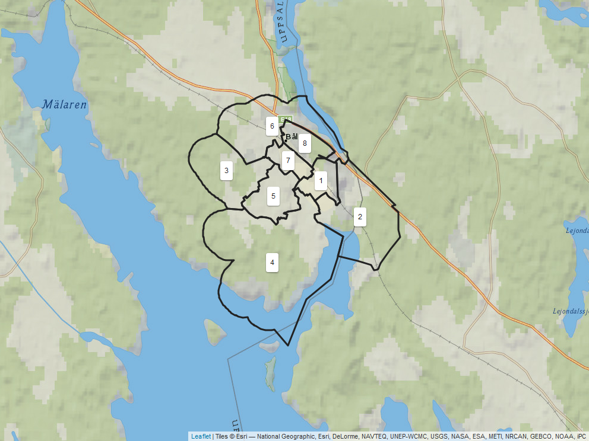

Table 2.1: Nyckel mellan kod och områden.

| # | Områdets namn | Områdets kod |
| --- | --- | --- |
| 1 | Centrala Bålsta | 0305C1040 |
| 2 | Kalmarsand | 0305C1020 |
| 3 | Skörby | 0305C1050 |
| 4 | Södra Bålsta | 0305C1010 |
| 5 | Västerdalen | 0305C1030 |
| 6 | Västerskog | 0305C1080 |
| 7 | Västerängen | 0305C1060 |
| 8 | Åsen | 0305C1070 |

I Tabell 2.3 återfinns befolkning, antal respondenter och andelen svarande av befolkningen i Bålsta. Andelen svarande ska ej förväxlas med svarsfrekvens (hur många av de tillfrågade som valde att svara på enkäten). Respondenternas kön och ålder per område finns redovisade i Tabell 2.4.

Table 2.2: Antal respondenter per månad under enkätundersökningens period.

| År | Månad | Antal respondenter |
| --- | --- | --- |
| 2021 | Januari | 7 |
| 2021 | Februari | 6 |
| 2021 | Mars | 3 |
| 2021 | April | 5 |
| 2021 | Maj | 170 |
| 2021 | Juni | 266 |
| 2021 | Juli | 93 |
| 2021 | Augusti | 71 |

Table 2.3: Antal svar jämfört med befolkningen (15–85 år) i respektive område.

| Område | Respondenter | Befolkning | Andel av befolkningen (%) |
| --- | --- | --- | --- |
| Centrala Bålsta | 66 | 1 244 | 5,3 |
| Kalmarsand | 58 | 1 271 | 4,6 |
| Skörby | 51 | 1 817 | 2,8 |
| Södra Bålsta | 73 | 2 290 | 3,2 |
| Västerdalen | 91 | 2 407 | 3,8 |
| Västerskog | 68 | 1 231 | 5,5 |
| Västerängen | 136 | 2 089 | 6,5 |
| Åsen | 78 | 1 326 | 5,9 |
| Totalt | 621 | 13 675 | 4,5 |

Andelen svarande av befolkningen (15–85 år) var i genomsnitt 5 procent. Störst andel svarande återfanns i Västerängen, med upp emot 7 procent. Särskilt låg andel svarande återfanns i Skörby och Södra Bålsta, där andelen svarande var ner emot 3 procent.

Table 2.4: Antal svar per kön och åldersgrupp.

| Område | Respondenter | Män | Kvinnor | 15–24 år | 25–64 år | 65–85 år |
| --- | --- | --- | --- | --- | --- | --- |
| Centrala Bålsta | 66 | 27 | 39 | 5 | 39 | 22 |
| Kalmarsand | 58 | 28 | 30 | 2 | 32 | 24 |
| Skörby | 51 | 23 | 28 | 5 | 26 | 20 |
| Södra Bålsta | 73 | 34 | 39 | 3 | 51 | 19 |
| Västerdalen | 91 | 47 | 43 | 6 | 43 | 42 |
| Västerskog | 68 | 29 | 39 | 5 | 34 | 29 |
| Västerängen | 136 | 69 | 67 | 9 | 69 | 58 |
| Åsen | 78 | 39 | 39 | 4 | 40 | 34 |
| Totalt | 621 | 296 | 324 | 39 | 334 | 248 |

Eftersom svarsbenägenheten varierar mellan olika grupper av invånare kan viss skevhet i representationen uppstå, trots att urvalet från början gjorts på ett representativt sätt. Genom att använda en mixad insamlingsmetod, där fysisk post, telefon och sms har använts för att nå respondenterna, uppger Svensk kollektivtrafik att svarsunderlaget håller en bättre representativitet än traditionella underskningar. Därmed är viktning mot kön, ålder och urvalsområde inte ansetts vara nödvändig.

Notera antalet respondenter per område. För att säkra slutsatser ska kunna dras krävs minst 50 respondenter. I områden med mycket litet antal respondenter kan det vara problematiskt att dra generella slutsatser. Resultat för områden med få antal respondenter nedan i resultatavsnittet bör tas med försiktighet. Även när data delas in i exempelvis åldersgrupper kan urvalet vara problematiskt lågt. Åldersgrupp 15–24 år har väldigt litet underlag, vilket bör beaktas i analysen.

# 3 Resultat

Nedan presenteras en sammanställning av resultat från resvaneundersökningen.

## 3.1 Körkort och biltillgång

Valet att färdas med bil, buss eller cykel eller att promenera är beroende av en mängd faktorer, såsom transportsystemets utbud och standard, attityder och kunskap, restriktioner och vanor. En avgörande faktor för färdmedelsvalet är körkortsinnehav och biltillgång.

Table 3.1: Andel respondenter med körkort och biltillgång.

| Område | Körkort (%) | Biltillgång (%) |
| --- | --- | --- |
| Centrala Bålsta | 55 | 65 |
| Kalmarsand | 94 | 95 |
| Skörby | 100 | 98 |
| Södra Bålsta | 91 | 99 |
| Västerdalen | 89 | 96 |
| Västerskog | 91 | 93 |
| Västerängen | 81 | 85 |
| Åsen | 80 | 94 |
| Totalt | 84 | 90 |

## 3.2 Antal resor

En genomsnittlig dag gjorde 57 procent av personer 15–85 år bosatta i Bålsta åtminstone en resa och totalt genomfördes 23 584 resor. Det motsvarar 2 resor per person och dag. I Tabell 3.2 framgår andel personer som rest och deras antal resor per dag redovisat per kön och ålderskategori.

Andelen som rest bland män och kvinnor var i samma storleksordning. Bland de som reser var dessutom antalet resor per dag snarlikt mellan kvinnor och män. I åldersgruppen 15–24 år var andelen som rest 69 procent, vilket är mer än övriga åldersgrupper.

Table 3.2: Antal resor per dag och resenärsgrupp.

| Grupp | Andel personer som rest (%) | Resor per dag och person | Resor per dag och person (enbart de som rest) | Befolkning | Antal resor |
| --- | --- | --- | --- | --- | --- |
| **Kön** |  |  |  |  |  |
| Kvinna | 54 | 1,7 | 3,1 | 6 870 | 11 344 |
| Man | 60 | 1,8 | 3,0 | 6 805 | 12 254 |
| **Ålder** |  |  |  |  |  |
| 15–24 år* | 69 | 2,1 | 3,0 | 3 280 | 6 728 |
| 25–64 år | 61 | 1,9 | 3,1 | 6 929 | 13 111 |
| 65–85 år | 49 | 1,4 | 3,0 | 2 279 | 3 299 |
| **Totalt** |  |  |  |  |  |
| Alla | 56 | 1,7 | 3,1 | 13 675 | 23 584 |

* Baseras på särskilt lågt antal respondenter.

## 3.3 Resornas fördelning på färdsätt

I Figur 3.1 framgår att bil var det vanligaste färdmedlet i Bålsta och stod för 82 procent av alla resor. Detta var också det vanligaste färdmedlet i varje enskilda delområde. Störst andel återfanns i Skörby, med 97 procent. Särskilt låg andel bilresor återfanns i Centrala Bålsta och Västerängen, där andelen var ner emot 50 procent.

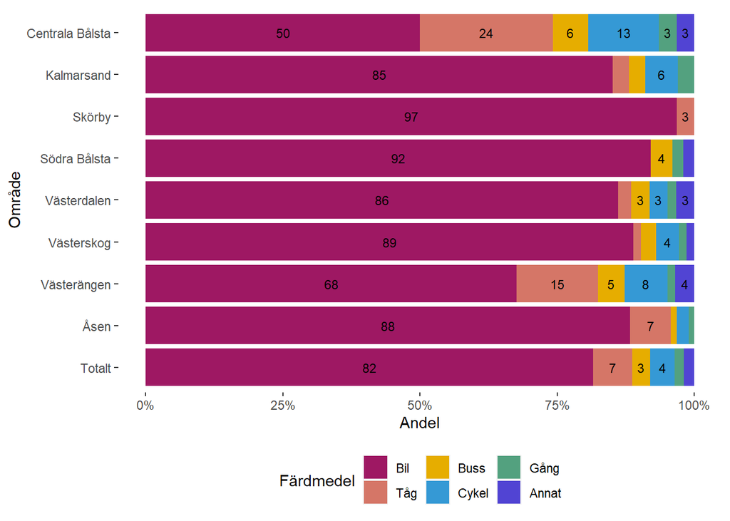

Figure 3.1: Resornas färdmedelsfördelning per område.

## 3.4 Kombinationsresor

En resa kan omfatta flera olika färdmedel. Ett färdmedel används som huvudfärdmedel, medan resterande utgör anslutningsresor. Totalt har 1,7 procent av resorna gjorts med fler än ett färdmedel. För vissa resor har gång rapporterats in som delresa. Eftersom de flesta resor rimligtvis omfattar en gångresa, har dessa kombinationsresor dock exkluderats i avsnittet. Nedan i Figur 3.2 framgår hur stor andel av kombinationsresorna som gjorts med respektive kombination av färdmedel.

Vanligen är kollektivtrafik ett sådant trafikslag som kräver att anslutningsresor görs för att resenären ska kunna ta sig till hållplatsen. Nedan i Figur 3.3 redovisas kollektivtrafikresornas anslutningsresor. För 78 procent av kollektivtrafiksresorna har respondenterna inte uppgett några anslutnignsresor (annat än eventuellt gångresor).

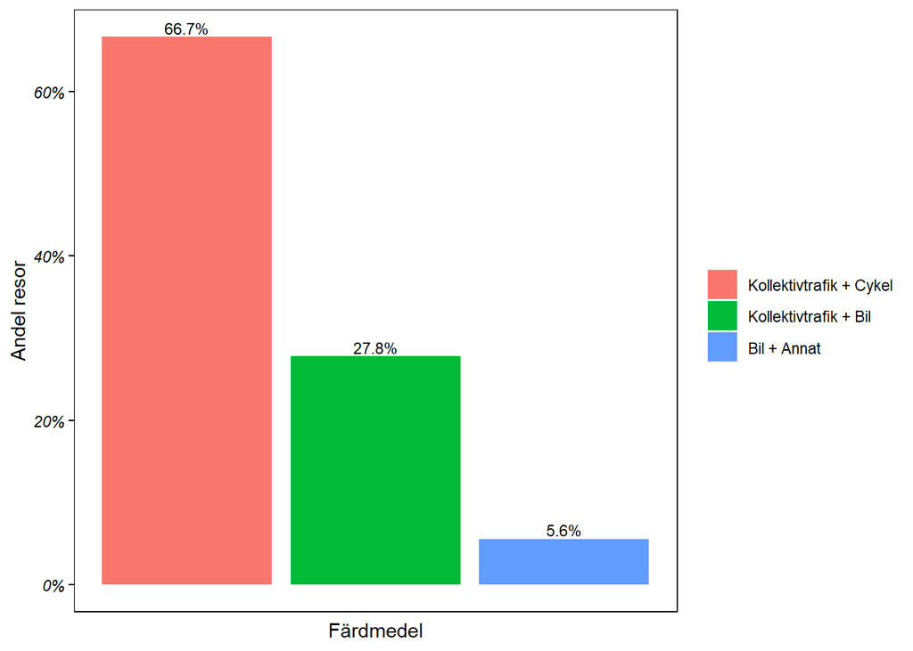

Figure 3.2: Enskilda kombinationsresor i andel av alla kombinationsresor. Kombinationsresor med gång som anslutningsresa har exkluderats.

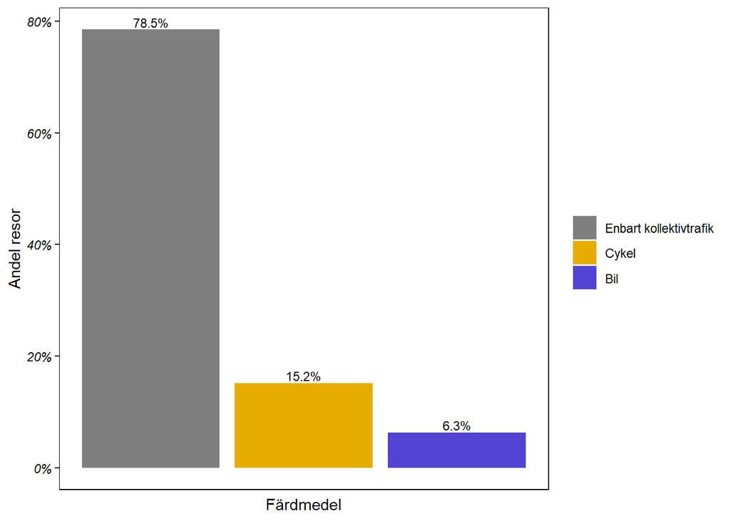

Figure 3.3: Anslutningsresor för kollektivtrafiksresor uttryckt i andelar av alla resor som gjorts med kollektivtrafik som huvudfärdmedel. I *Enbart kollektivtrafik* ingår resor där gång rapporterterats in som anslutningsresa.

## 3.5 Bakgrundfrågor

Nedan följer sammanställningar av resultat kopplade till respondenternas egenskaper.

### 3.5.1 Färdsätt efter kön

I Figur 3.4 visas färdmedelsandelar per kön. Andelen män och kvinnor i undersökningen var 48 respektive 52 procent. Hur de reser brukar skilja sig åt. Bland män stod bil för en större del av resorna än bland kvinnor. För kvinnor var istället cykel vanligare än bland män.

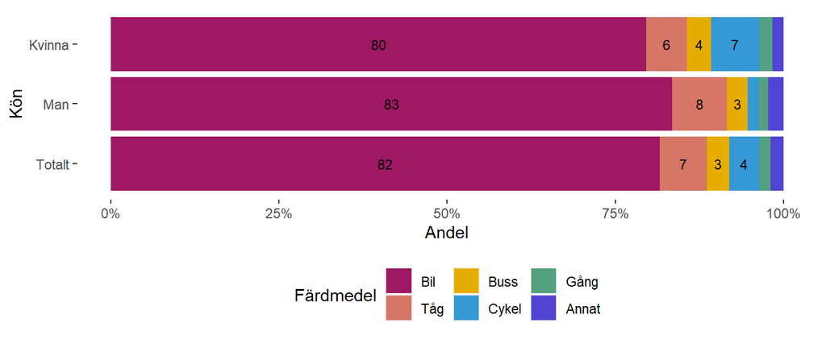

Figure 3.4: Resornas färdmedelsfördelning per kön. Eventuella respondenter med okänt kön redovisas inte.

### 3.5.2 Färdsätt efter ålder

Åldersgruppen 15–24 år utgjorde 26 procent, gruppen 25–64 år 55 procent och gruppen 65–85 år 18 procent av den undersökta befolkningen. I Figur 3.5 nedan jämförs färdmedelsandelar mellan olika åldersgrupper.

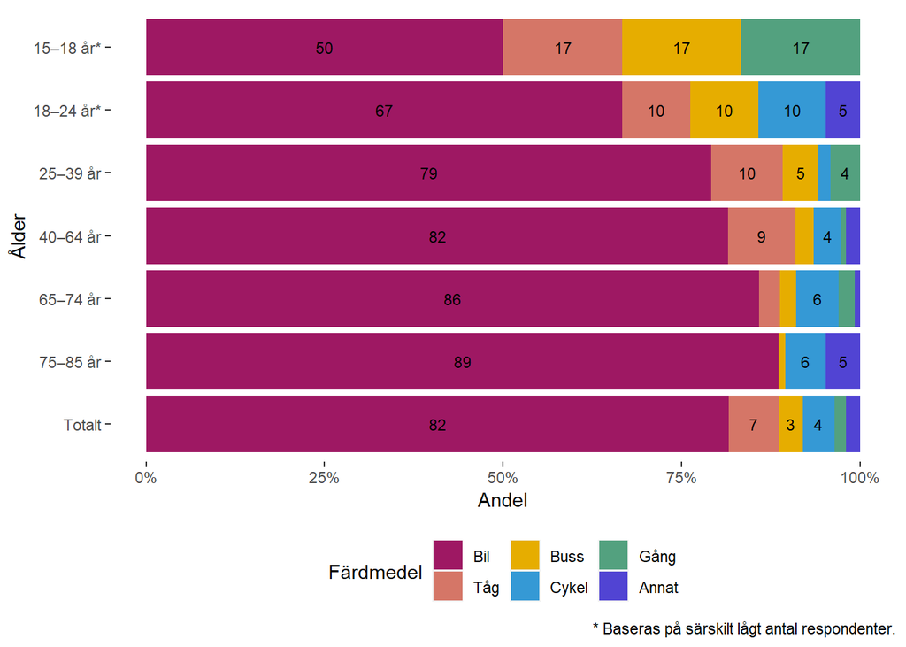

Figure 3.5: Resornas färdmedelsfördelning per åldersgrupp.

De yngsta åkte i större utsträckning med kollektivtrafiken än övriga grupper. Kollektivtrafiksandelen sjunker sedan med stigande ålder. När det gäller cykelresor var det däremot åldersgruppen 18–24 år som gjorde en större andel cykelresor än övriga grupper. Andelen bilresor ökar med stigande ålder och var störst i ålderskategorin 75–85 år, där 89 procent av resorna gjordes med bil.

### 3.5.3 Färdsätt efter sysselsättning

I åldern 15–85 år var 54 procent förvärvsarbetande, 5 procent studerande och 35 procent pensionärer. I Figur 3.6 nedan presenteras färdmedelsfördelningen per sysselsättningsgrupp. Bil var det vanligaste färdmedlet för samtliga grupper. Bil användes i störst utsträckning av gruppen *pensionär* och minst i gruppen *arbetssökande*. Kollektivtrafiksandelen var störst i gruppen *föräldraledig*. Cykelandelen var däremot störst i gruppen *arbetssökande*.

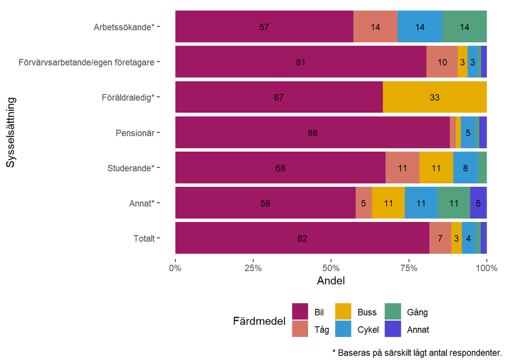

Figure 3.6: Resornas färdmedelsfördelning per sysselsättning

### 3.5.4 Färdsätt efter ärende

Resans *ärende* är syftet med resan och kan bland annat vara *inköp av dagligvaror* eller *arbete*. Kategorierna är valda för att alla typer av resor ska kunna falla in under en kategori. Ifall inget passande ärende fanns, kunde respondenten välja *annat ärende*. 4 procent av resorna har blivit kategoriserade som *annat ärende*.

Resor till bostaden utgör normalt sett en stor del av alla resor. I denna mätning var andelen resor till bostaden 41 procent, medan andelen arbetsresor var 15 procent. Av resor till arbetet var 65 procent bilresor, 26 procent kollektivtrafiksresor och 6 procent cykelresor.

I Figur 3.7 presenteras färdmedelsandelar för respektive ärendetyp. Bil valdes i störst utsträckning för ärendet *tjänsteresa (resa i arbetet)* (100 %). För ärende *studier (till skola/studier)* användes dock bil i lägst utsträckning (33 %). Istället gjordes dessa resor i större utsträckning med kollektivtrafik (67 %).

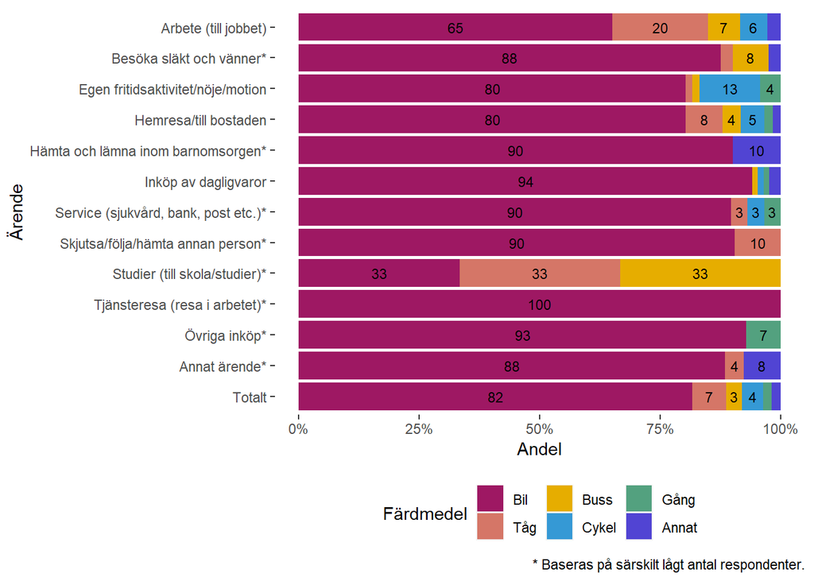

Figure 3.7: Resornas färdmedelsfördelning per ärende

## 3.6 Reslängd

I enkäten har intervjupersonerna fått fylla i plats för resmål, som sparats i statistiken i form av koordinater. Dessa koordinater har använts för att uppskatta avstånd för varje resa med respektive färdmedel. Det partiella bortfallet på grund av okänd reslängd var 62 procent. Den sammanlagda ressträckan som utövas av alla individer mäts i färdmedelskilometer. I det här fallet betecknar detta det totala antalet kilometer som invånarna inom respektive område har förflyttat sig med respektive färdmedel under en genomsnittsdag.

Table 3.3: Reslängd per resa och totalt sammanlagd ressträcka per färdmedel.

| Färdmedel | Median | Medel | Totalt antal resor | Totalt antal färdmedelskilometer | Antal observationer |
| --- | --- | --- | --- | --- | --- |
| Bil | 17 | 28 | 13 600 | 384 395 | 557 |
| Tåg* | 47 | 43 | 900 | 40 008 | 48 |
| Cykel* | 2 | 4 | 500 | 1 988 | 28 |
| Buss* | 12 | 21 | 500 | 9 596 | 21 |
| Gång* | 2 | 3 | 200 | 723 | 10 |

* Baseras på särskilt lågt antal respondenter.

I Bålsta var en medianresa 15 kilometer lång. Längst var resorna med tåg, med en medianresa på 47 kilometer. Kortast var resorna med gång, med en medianresa på 2 kilometer. Notera att tåg, cykel, buss och gång har väldigt få observationer. Slutsatserna om dessa färdmedel bör tas med försiktighet.

Bil var det vanligaste färdmedlet med en total sammanlagd ressträcka på 384 395 kilometer, vilket motsvarar 88 procent av den totala ressträckan för samtliga trafikslag för boende i Bålsta.

För boende i Skörby var en medianresa kortare än i andra delområden (5 km). De längsta resorna återfanns i Centrala Bålsta, med en medianresa på 44 kilometer. I Västerdalen gjordes den största sammanlagda förflyttningen på 103 000 kilometer, medan Åsen stod för den minsta sammanlagda förflyttningen på 31 000 kilometer.

Table 3.4: Reslängd per resa och totalt antal färdmedelskilometer per område.

| Område | Median | Medel | Totalt antal resor | Totalt antal färdmedelskilometer | Antal observationer |
| --- | --- | --- | --- | --- | --- |
| Centrala Bålsta | 44 | 37 | 1 100 | 40 816 | 56 |
| Kalmarsand | 20 | 28 | 1 500 | 41 984 | 64 |
| Skörby | 5 | 29 | 2 300 | 65 898 | 60 |
| Södra Bålsta | 13 | 20 | 3 000 | 62 070 | 94 |
| Västerdalen | 27 | 33 | 3 100 | 102 951 | 112 |
| Västerskog | 20 | 30 | 1 200 | 36 371 | 62 |
| Västerängen | 12 | 26 | 2 100 | 55 054 | 135 |
| Åsen | 9 | 21 | 1 500 | 30 805 | 81 |

I Figur 3.8 nedan presenteras färdmedelsfördelning per reslängd. Andelen resor som genomfördes med bil var störst vid ett avstånd på 5–10 kilometer. Andelen resor med tåg var störst vid ett avstånd på 25–50 kilometer. Cykelandelen var som störst för resor på 0–2 kilometer.

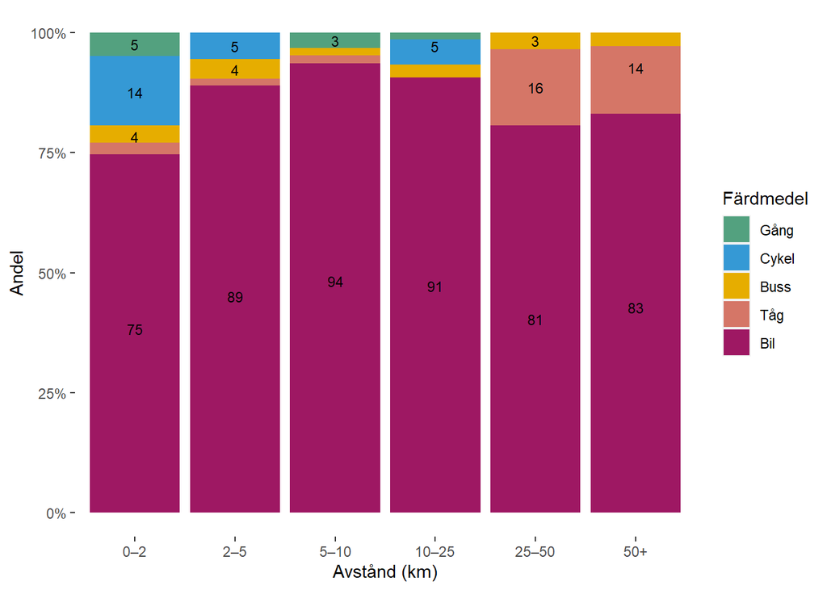

Figure 3.8: Resornas färdmedelsfördelning beroende på reslängd, där reslängden är indelad i avståndsklasser.

### 3.6.1 Reserelationer inom Bålsta tätort

42 procent av resorna som boende i Bålsta gjorde, skedde inom Bålsta. Den vanligaste förekommande resan inom ett delområde skedde i Södra Bålsta, vilket motsvarar 2 procent av alla resor. Den vanligaste resan mellan två delområden var från Kalmarsand till Västerängen motsvarande 6 procent av alla resor i Bålsta. I Tabell 3.5 framgår de vanligaste reserelationerna inom Bålsta och dess andelar av det totala antalet resor. Observera att det fanns ett bortfall på 51 procent i underlaget på grund av att vissa resor saknar information om avrese- och/eller ankomstplats.

Table 3.5: Fördelning av resorna inom Bålsta. Radrubriker visar var resar börjar och kolumnrubriker visar var resan slutar.

|  | Centrala Bålsta | Kalmarsand | Västerängen | Södra Bålsta | Västerdalen | Västerskog | Åsen | Skörby | Totalt |
| --- | --- | --- | --- | --- | --- | --- | --- | --- | --- |
| Centrala Bålsta | 2% | 3% | 4% | 3% | 2% | 2% | 3% | 3% | 22% |
| Kalmarsand | 3% | 2% | 6% | 3% | 4% | 1% | 1% | 1% | 21% |
| Västerängen | 5% | 5% | 2% | 1% | 2% | 1% | 1% | 1% | 18% |
| Södra Bålsta | 2% | 3% | 1% | 2% | 0% | 0% | 0% | 0% | 9% |
| Västerdalen | 2% | 4% | 2% | 0% | 0% | 1% | 0% | 0% | 9% |
| Västerskog | 2% | 1% | 1% | 0% | 1% | 1% | 0% | 1% | 8% |
| Åsen | 4% | 1% | 1% | 1% | 0% | 0% | 0% | 0% | 7% |
| Skörby | 3% | 2% | 1% | 0% | 0% | 0% | 0% | 0% | 6% |
| Totalt | 24% | 20% | 17% | 10% | 10% | 7% | 6% | 6% | 100% |

### 3.6.2 Utpendling från Bålsta tätort

Av alla resor som utgår från Bålsta tätort, görs 30 procent till andra tätorter. Nedan sammanställs utpendlingen för boende i Bålsta tätort uttryckt som andelar av resorna som startar i Bålsta tätort. I Figur 3.9 redovisas utpendlingen till andra tätorter och i Figur 3.10 till andra kommuner. Den vanligaste tätorten för utpendlingsresor var Stockholm, vilket också var den vanligaste kommunen för utpendlingsresor. Anledningen till att inte inpendling kan redovisas är att urvalet ur resvaneundersökningen enbart omfattar boende i Bålsta tätort.

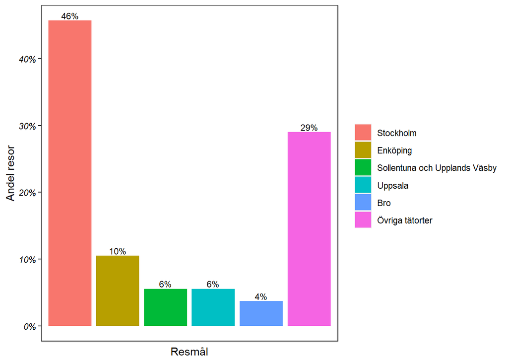

Figure 3.9: Andel utpendlingsresor från Bålsta tätort till andra tätorter.

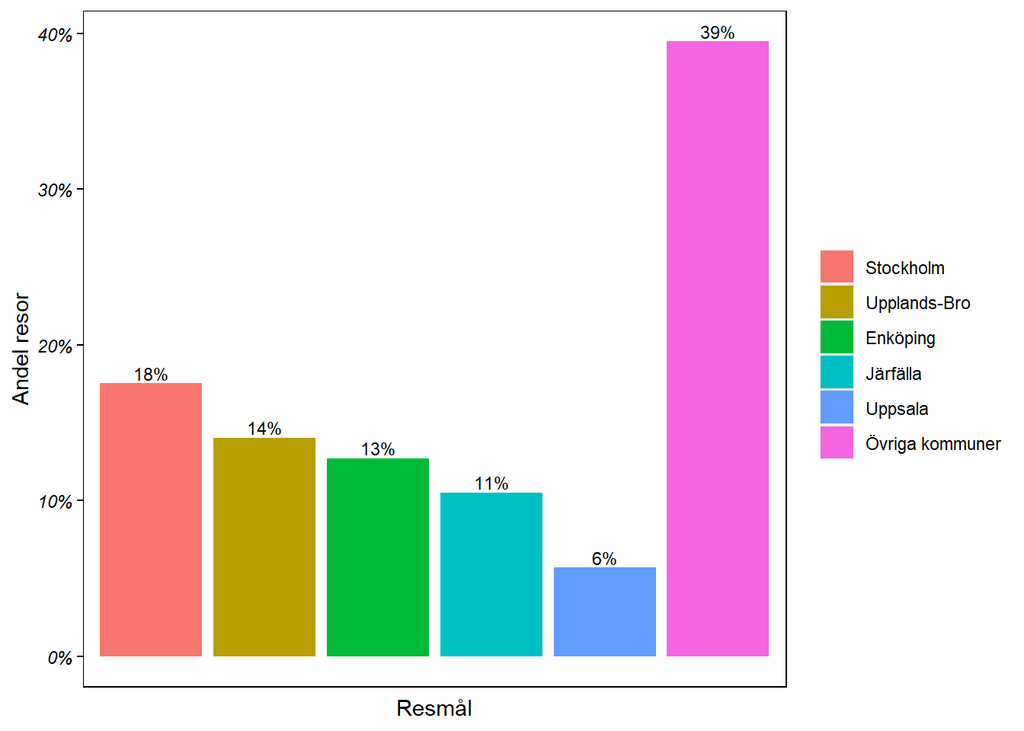

Figure 3.10: Andel utpendlingsresor från Bålsta tätort till andra kommuner.

# 4 Bilagor

## 4.1 Karta

Nedan följer en karta över de delområden som Bålsta inbegriper.

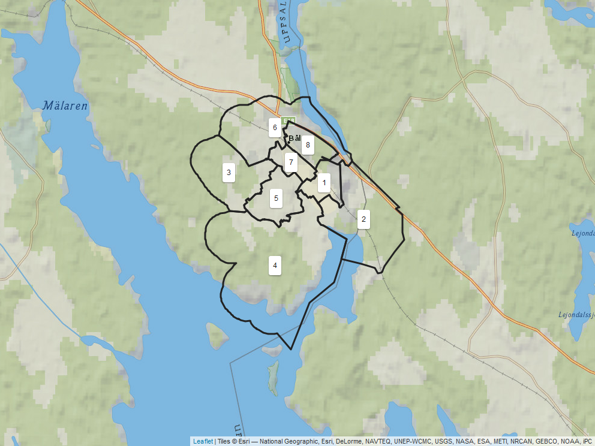

Karta över alla områden i rapporten.

Table 4.1: Nyckel mellan kod och områden.

| # | Områdets namn | Områdets kod |
| --- | --- | --- |
| 1 | Centrala Bålsta | 0305C1040 |
| 2 | Kalmarsand | 0305C1020 |
| 3 | Skörby | 0305C1050 |
| 4 | Södra Bålsta | 0305C1010 |
| 5 | Västerdalen | 0305C1030 |
| 6 | Västerskog | 0305C1080 |
| 7 | Västerängen | 0305C1060 |
| 8 | Åsen | 0305C1070 |

## 4.2 Detaljerade tabeller

Nedan följer tabeller som avser att ge en mer detaljerad bild av resvaneundersökningen.

Table 4.2: Antal resor per sysselsättning och område, redovisat uppräknat på antalet invånare.

| Område | Annat | Arbetssökande | Förvärvsarbetande/egen företagare | Föräldraledig | Pensionär | Studerande | Vet ej/Vill ej svara | Totalt |
| --- | --- | --- | --- | --- | --- | --- | --- | --- |
| Centrala Bålsta | 60 | 60 | 602 | 40 | 401 | 80 | 0 | 1 244 |
| Kalmarsand | 57 | 38 | 569 | 0 | 493 | 76 | 38 | 1 271 |
| Skörby | 29 | 0 | 894 | 0 | 779 | 115 | 0 | 1 817 |
| Södra Bålsta | 0 | 92 | 1 511 | 46 | 481 | 160 | 0 | 2 290 |
| Västerdalen | 118 | 0 | 1 144 | 0 | 1 006 | 79 | 59 | 2 407 |
| Västerskog | 34 | 0 | 718 | 34 | 445 | 0 | 0 | 1 231 |
| Västerängen | 59 | 44 | 1 236 | 0 | 633 | 118 | 0 | 2 089 |
| Åsen | 0 | 28 | 663 | 0 | 550 | 85 | 0 | 1 326 |
| Totalt | 360 | 265 | 7 349 | 114 | 4 792 | 701 | 95 | 13 675 |

Table 4.3: Sysselsättning per område, redovisat i andelar uttryckt i procent per område.

| Område | Annat | Arbetssökande | Förvärvsarbetande/egen företagare | Föräldraledig | Pensionär | Studerande | Vet ej/Vill ej svara |
| --- | --- | --- | --- | --- | --- | --- | --- |
| Centrala Bålsta | 5% | 5% | 48% | 3% | 32% | 6% | 0% |
| Kalmarsand | 4% | 3% | 45% | 0% | 39% | 6% | 3% |
| Skörby | 2% | 0% | 49% | 0% | 43% | 6% | 0% |
| Södra Bålsta | 0% | 4% | 66% | 2% | 21% | 7% | 0% |
| Västerdalen | 5% | 0% | 48% | 0% | 42% | 3% | 2% |
| Västerskog | 3% | 0% | 58% | 3% | 36% | 0% | 0% |
| Västerängen | 3% | 2% | 59% | 0% | 30% | 6% | 0% |
| Åsen | 0% | 2% | 50% | 0% | 41% | 6% | 0% |
| Totalt | 3% | 2% | 54% | 1% | 35% | 5% | 1% |

Table 4.4: Körkortsinnehav per område, redovisat uppräknat på antalet invånare samt i andelar uttryckt i procent.

| Område | Ja | Nej | Totalt | Ja (radprocent) | Nej (radprocent) |
| --- | --- | --- | --- | --- | --- |
| Centrala Bålsta | 720 | 524 | 1 244 | 58% | 42% |
| Kalmarsand | 1 200 | 71 | 1 271 | 94% | 6% |
| Skörby | 1 817 | 0 | 1 817 | 100% | 0% |
| Södra Bålsta | 2 082 | 208 | 2 290 | 91% | 9% |
| Västerdalen | 2 149 | 258 | 2 407 | 89% | 11% |
| Västerskog | 1 119 | 112 | 1 231 | 91% | 9% |
| Västerängen | 1 783 | 306 | 2 089 | 85% | 15% |
| Åsen | 1 061 | 265 | 1 326 | 80% | 20% |
| Totalt | 11 690 | 1 985 | 13 675 | 85% | 15% |

Table 4.5: Bildisposition per område, redovisat uppräknat på antalet invånare.

| Område | Ja, lånar av vänner/bekanta | Ja, tjänstebil/leasingbil | Ja, äger bil | Ja, är med i en bilpool | Nej | Vill ej svara | Totalt |
| --- | --- | --- | --- | --- | --- | --- | --- |
| Centrala Bålsta | 0 | 80 | 903 | 0 | 261 | 0 | 1 244 |
| Kalmarsand | 38 | 38 | 1 157 | 0 | 38 | 0 | 1 271 |
| Skörby | 58 | 115 | 1 586 | 0 | 58 | 0 | 1 817 |
| Södra Bålsta | 46 | 160 | 2 038 | 0 | 0 | 46 | 2 290 |
| Västerdalen | 0 | 39 | 2 289 | 0 | 0 | 79 | 2 407 |
| Västerskog | 68 | 68 | 1 043 | 0 | 51 | 0 | 1 231 |
| Västerängen | 29 | 59 | 1 898 | 0 | 103 | 0 | 2 089 |
| Åsen | 42 | 141 | 1 072 | 42 | 28 | 0 | 1 326 |
| Totalt | 284 | 701 | 11 970 | 57 | 549 | 114 | 13 675 |

Table 4.6: Bilinnehav per område, redovisat i andelar uttryckt i procent.

| Område | Ja, lånar av vänner/bekanta | Ja, tjänstebil/leasingbil | Ja, äger bil | Ja, är med i en bilpool | Nej | Vill ej svara |
| --- | --- | --- | --- | --- | --- | --- |
| Centrala Bålsta | 0% | 6% | 73% | 0% | 21% | 0% |
| Kalmarsand | 3% | 3% | 91% | 0% | 3% | 0% |
| Skörby | 3% | 6% | 87% | 0% | 3% | 0% |
| Södra Bålsta | 2% | 7% | 89% | 0% | 0% | 2% |
| Västerdalen | 0% | 2% | 95% | 0% | 0% | 3% |
| Västerskog | 6% | 6% | 85% | 0% | 4% | 0% |
| Västerängen | 1% | 3% | 91% | 0% | 5% | 0% |
| Åsen | 3% | 11% | 81% | 3% | 2% | 0% |
| Totalt | 2% | 5% | 88% | 0% | 4% | 1% |

Table 4.7: Färdmedel per åldersgrupp, redovisat uppräknat på antalet invånare.

| Ålder | Bil | Tåg | Buss | Cykel | Gång | Annat | Totalt |
| --- | --- | --- | --- | --- | --- | --- | --- |
| 15–18 år* | 611 | 204 | 204 | 0 | 204 | 0 | 1 222 |
| 18–24 år* | 1 372 | 196 | 196 | 196 | 0 | 98 | 2 058 |
| 25–39 år | 2 318 | 293 | 146 | 49 | 122 | 0 | 2 928 |
| 40–64 år | 3 263 | 375 | 104 | 155 | 26 | 78 | 4 001 |
| 65–74 år | 1 350 | 47 | 35 | 94 | 35 | 12 | 1 573 |
| 75–85 år | 625 | 0 | 7 | 40 | 0 | 34 | 706 |
| Totalt | 11 156 | 966 | 455 | 606 | 227 | 265 | 13 675 |

* Baseras på särskilt lågt antal respondenter.

Table 4.8: Färdmedel per åldersgrupp, redovisat i andelar uttryckt i procent.

| Ålder | Bil | Tåg | Buss | Cykel | Gång | Annat |
| --- | --- | --- | --- | --- | --- | --- |
| 15–18 år* | 50% | 17% | 17% | 0% | 17% | 0% |
| 18–24 år* | 67% | 10% | 10% | 10% | 0% | 5% |
| 25–39 år | 79% | 10% | 5% | 2% | 4% | 0% |
| 40–64 år | 82% | 9% | 3% | 4% | 1% | 2% |
| 65–74 år | 86% | 3% | 2% | 6% | 2% | 1% |
| 75–85 år | 89% | 0% | 1% | 6% | 0% | 5% |
| Totalt | 82% | 7% | 3% | 4% | 2% | 2% |

* Baseras på särskilt lågt antal respondenter.

Table 4.9: Färdmedel per kön, redovisat uppräknat på antalet invånare.

| Kön | Bil | Tåg | Buss | Cykel | Gång | Annat | Totalt |
| --- | --- | --- | --- | --- | --- | --- | --- |
| Kvinna | 5 470 | 416 | 246 | 492 | 132 | 114 | 6 870 |
| Man | 5 680 | 553 | 210 | 114 | 95 | 152 | 6 805 |
| Totalt | 11 156 | 966 | 455 | 606 | 227 | 265 | 13 675 |

Table 4.10: Färdmedel per kön, redovisat i andelar uttryckt i procent.

| Kön | Bil | Tåg | Buss | Cykel | Gång | Annat |
| --- | --- | --- | --- | --- | --- | --- |
| Kvinna | 80% | 6% | 4% | 7% | 2% | 2% |
| Man | 83% | 8% | 3% | 2% | 1% | 2% |
| Totalt | 82% | 7% | 3% | 4% | 2% | 2% |

Table 4.11: Färdmedelsandelar per område, redovisat uppräknat på antalet invånare.

| Område | Bil | Tåg | Buss | Cykel | Gång | Annat | Totalt |
| --- | --- | --- | --- | --- | --- | --- | --- |
| Centrala Bålsta | 622 | 301 | 80 | 161 | 40 | 40 | 1 244 |
| Kalmarsand | 1 081 | 38 | 38 | 76 | 38 | 0 | 1 271 |
| Skörby | 1 759 | 58 | 0 | 0 | 0 | 0 | 1 817 |
| Södra Bålsta | 2 107 | 0 | 92 | 0 | 46 | 46 | 2 290 |
| Västerdalen | 2 072 | 59 | 79 | 79 | 39 | 79 | 2 407 |
| Västerskog | 1 094 | 17 | 34 | 51 | 17 | 17 | 1 231 |
| Västerängen | 1 412 | 309 | 103 | 162 | 29 | 74 | 2 089 |
| Åsen | 1 171 | 99 | 14 | 28 | 14 | 0 | 1 326 |
| Totalt | 11 156 | 966 | 455 | 606 | 227 | 265 | 13 675 |

Table 4.12: Antal resor per färdmedel och område, redovisat i andelar uttryckt i procent.

| Område | Bil | Tåg | Buss | Cykel | Gång | Annat |
| --- | --- | --- | --- | --- | --- | --- |
| Centrala Bålsta | 50% | 24% | 6% | 13% | 3% | 3% |
| Kalmarsand | 85% | 3% | 3% | 6% | 3% | 0% |
| Skörby | 97% | 3% | 0% | 0% | 0% | 0% |
| Södra Bålsta | 92% | 0% | 4% | 0% | 2% | 2% |
| Västerdalen | 86% | 2% | 3% | 3% | 2% | 3% |
| Västerskog | 89% | 1% | 3% | 4% | 1% | 1% |
| Västerängen | 68% | 15% | 5% | 8% | 1% | 4% |
| Åsen | 88% | 7% | 1% | 2% | 1% | 0% |
| Totalt | 82% | 7% | 3% | 4% | 2% | 2% |

Table 4.13: Antal resor per resärende och område, redovisat uppräknat på antalet invånare.

| Område | Annat ärende | Arbete (till jobbet) | Besöka släkt och vänner | Egen fritidsaktivitet/nöje/motion | Hemresa/till bostaden | Hämta och lämna inom barnomsorgen | Inköp av dagligvaror | Service (sjukvård, bank, post etc.) | Skjutsa/följa/hämta annan person | Studier (till skola/studier) | Tjänsteresa (resa i arbetet) | Övriga inköp | Totalt |
| --- | --- | --- | --- | --- | --- | --- | --- | --- | --- | --- | --- | --- | --- |
| Centrala Bålsta | 20 | 237 | 99 | 79 | 573 | 0 | 138 | 59 | 20 | 20 | 0 | 0 | 1 244 |
| Kalmarsand | 55 | 184 | 55 | 111 | 479 | 37 | 147 | 74 | 55 | 0 | 55 | 18 | 1 271 |
| Skörby | 29 | 202 | 202 | 115 | 663 | 0 | 433 | 58 | 0 | 0 | 29 | 87 | 1 817 |
| Södra Bålsta | 69 | 321 | 69 | 229 | 893 | 46 | 321 | 69 | 137 | 23 | 0 | 114 | 2 290 |
| Västerdalen | 79 | 276 | 59 | 355 | 1 065 | 0 | 237 | 158 | 59 | 0 | 0 | 118 | 2 407 |
| Västerskog | 51 | 171 | 85 | 120 | 513 | 34 | 85 | 34 | 34 | 0 | 17 | 85 | 1 231 |
| Västerängen | 102 | 424 | 102 | 161 | 891 | 15 | 234 | 58 | 44 | 15 | 0 | 44 | 2 089 |
| Åsen | 56 | 183 | 99 | 155 | 536 | 42 | 99 | 42 | 42 | 0 | 0 | 71 | 1 326 |
| Totalt | 490 | 2 053 | 753 | 1 337 | 5 651 | 188 | 1 582 | 546 | 396 | 57 | 94 | 527 | 13 675 |

Table 4.14: Resärende per område, redovisat i andelar uttryckt i procent per område.

| Område | Annat ärende | Arbete (till jobbet) | Besöka släkt och vänner | Egen fritidsaktivitet/nöje/motion | Hemresa/till bostaden | Hämta och lämna inom barnomsorgen | Inköp av dagligvaror | Service (sjukvård, bank, post etc.) | Skjutsa/följa/hämta annan person | Studier (till skola/studier) | Tjänsteresa (resa i arbetet) | Övriga inköp |
| --- | --- | --- | --- | --- | --- | --- | --- | --- | --- | --- | --- | --- |
| Centrala Bålsta | 2% | 19% | 8% | 6% | 46% | 0% | 11% | 5% | 2% | 2% | 0% | 0% |
| Kalmarsand | 4% | 14% | 4% | 9% | 38% | 3% | 12% | 6% | 4% | 0% | 4% | 1% |
| Skörby | 2% | 11% | 11% | 6% | 37% | 0% | 24% | 3% | 0% | 0% | 2% | 5% |
| Södra Bålsta | 3% | 14% | 3% | 10% | 39% | 2% | 14% | 3% | 6% | 1% | 0% | 5% |
| Västerdalen | 3% | 11% | 2% | 15% | 44% | 0% | 10% | 7% | 2% | 0% | 0% | 5% |
| Västerskog | 4% | 14% | 7% | 10% | 42% | 3% | 7% | 3% | 3% | 0% | 1% | 7% |
| Västerängen | 5% | 20% | 5% | 8% | 43% | 1% | 11% | 3% | 2% | 1% | 0% | 2% |
| Åsen | 4% | 14% | 7% | 12% | 40% | 3% | 7% | 3% | 3% | 0% | 0% | 5% |
| Totalt | 4% | 15% | 6% | 10% | 41% | 1% | 12% | 4% | 3% | 0% | 1% | 4% |

[^1]: https://www.svenskkollektivtrafik.se/verktyg-och-system/kollektivtrafikbarometern/
[^2]: https://developers.google.com/maps/documentation/directions/overview
[^3]: https://github.com/bjornsh/kollektivtrafikbarometer